# 2D Synthetic Dataset: Exploring SearchGraph

by: Eric S. Téllez

This demonstration shows `SearchGraph` on a 2D synthetic dataset. Being 2D, we can visualize the kNN neighborhoods directly, giving intuition about how the index behaves in regions of different density. We also demonstrate `closestpair` and `neardup`, two useful dataset-level operations.

```julia
using SimilaritySearch, SimSearchManifoldLearning, Plots, StatsBase, LinearAlgebra, Markdown, Random, Printf
```

```julia
n = 100_000
M = randn(Float16, 2, n)
db = MatrixDatabase(M)
dist = Dist.SqL2()   # evaluates in Float32 internally
size(M)
```

## Index construction

```julia
G = SearchGraph(dist, db)
ctx = SearchGraphContext(hyperparameters_callback=OptimizeParameters(MinRecall(0.99)))
index!(G, ctx)
optimize_index!(G, ctx, MinRecall(0.9))
```

**1**

Positional constructor: `SearchGraph(dist, db)`. The context controls caches and the hyperparameter-tuning callback.

**2**

Indexes all items in `db`.

**3**

Rebalances beam-search hyperparameters to target 90 % recall.

## Batch search

We define a small set of queries at various density regions and search their 30 nearest neighbors.

```julia
Q = VectorDatabase([Float32[-2,-2], Float32[2,-2], Float32[-2,0],
                    Float32[0, 2], Float32[0,0],  Float32[-3,3],
                    Float32[4, 4], Float32[1,0.5]])
ids, dists = searchbatch(G, ctx, Q, 30)   # returns (ids, dists) — each (30 × |Q|)
```

Please note how queries in low and high dense regions get very different neighborhood radii.

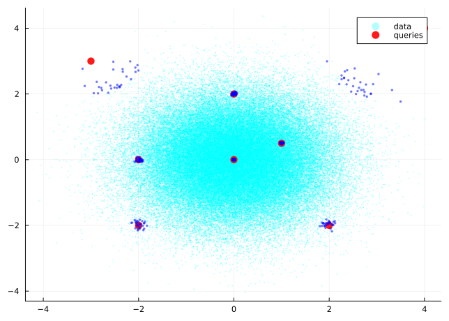

```julia
scatter(view(M, 1, :), view(M, 2, :); fmt=:png, c=:cyan, ma=0.3, ms=1, msw=0, label="data")
scatter!(getindex.(Q, 1), getindex.(Q, 2); c=:red, ma=0.9, ms=6, msw=0, label="queries")

for i in axes(ids, 2)
    col_ids = ids[:, i]
    X = M[:, col_ids]
    scatter!(view(X, 1, :), view(X, 2, :); c=:blue, ma=0.5, ms=2, msw=0, label="")
end

plot!(legend=:topright)
```

Since points are distributed across regions with disparate density, the 30-NN radius varies widely:

| query | x | y | radius (30-NN) |
| --- | --- | --- | --- |
| 1 | -2.0 | -2.0 | 0.1826 |
| 2 | 2.0 | -2.0 | 0.1938 |
| 3 | -2.0 | 0.0 | 0.1046 |
| 4 | 0.0 | 2.0 | 0.0768 |
| 5 | 0.0 | 0.0 | 0.0320 |
| 6 | -3.0 | 3.0 | 1.0361 |
| 7 | 4.0 | 4.0 | 2.4688 |
| 8 | 1.0 | 0.5 | 0.0402 |

## Closest pair

`closestpair` finds the globally closest pair of distinct items in the dataset in sub-quadratic time using the indexed graph.

```julia
i, j, d = closestpair(G, ctx)
println("Closest pair: items $i and $j, squared-L2 distance = ", d)
println("  item $i = ", G[i])
println("  item $j = ", G[j])
```

```
Closest pair: items 55698 and 1073, squared-L2 distance = 0.0
  item 55698 = Float16[0.576, 1.294]
  item 1073 = Float16[0.576, 1.294]
```

## Near-duplicate detection

`neardup` partitions the dataset into groups of near-duplicates: each group has a representative (center) and all items within `ε` of it. We use a radius derived from the 1-NN distance distribution.

```julia
# estimate a reasonable ε from a sample of 1-NN distances
sample_ids, sample_dists = searchbatch(G, ctx, SubDatabase(db, rand(1:n, 500)), 2)
ε = quantile(vec(sample_dists[2, :]), 0.01)   # very tight: ~1% of pairs

sel = neardup(dist, db, ε)
println("Groups (centers): ", length(sel.centers))
println("ε = ", ε)
```

[output not shown]

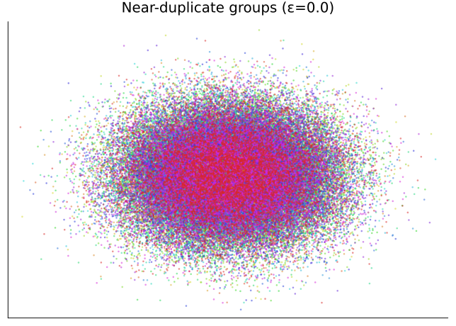

```julia
# visualize: color by group assignment
ncolors = length(sel.centers)
group_colors = [HSL(360 * i / ncolors, 0.7, 0.5) for i in 1:ncolors]

pt_colors = [group_colors[min(a, ncolors)] for a in sel.assign]
scatter(view(M, 1, :), view(M, 2, :); color=pt_colors, fmt=:png,
        ms=1.5, msw=0, ma=0.5, label="", title="Near-duplicate groups (ε=$(round(ε, digits=4)))",
        xticks=nothing, yticks=nothing)
```

## Environment and dependencies

```
Julia Version 1.12.7
Commit 6d172b025e4 (2026-08-15 08:05 UTC)
Build Info:
  Official https://julialang.org release
Platform Info:
  OS: Linux (x86_64-linux-gnu)
  CPU: 64 × Intel(R) Xeon(R) Silver 4216 CPU @ 2.10GHz
  WORD_SIZE: 64
  LLVM: libLLVM-18.1.7 (ORCJIT, cascadelake)
  GC: Built with stock GC
Threads: 64 default, 1 interactive, 64 GC (on 64 virtual cores)
Environment:
  JULIA_PROJECT = @.
  JULIA_NUM_THREADS = auto
  JULIA_LOAD_PATH = @:@stdlib
Status `~/Research/SimilaritySearchDemos/Project.toml`
  [aaaa29a8] Clustering v0.15.8
  [944b1d66] CodecZlib v0.7.9
  [a93c6f00] DataFrames v1.8.2
  [f67ccb44] HDF5 v0.17.3
  [0f8b85d8] JSON3 v1.14.3
  [23fbe1c1] Latexify v0.16.12
  [eb30cadb] MLDatasets v0.7.21
  [06eb3307] ManifoldLearning v0.9.0
⌅ [ca7969ec] PlotlyLight v0.11.1
  [91a5bcdd] Plots v1.41.7
  [27ebfcd6] Primes v0.5.7
  [92933f4c] ProgressMeter v1.11.0
  [ca7ab67e] SimSearchManifoldLearning v0.4.0 `../SimSearchManifoldLearning.jl`
  [053f045d] SimilaritySearch v1.2.0 `../SimilaritySearch.jl`
⌅ [2913bbd2] StatsBase v0.33.21
  [f3b207a7] StatsPlots v0.15.8
  [7f6f6c8a] TextSearch v1.1.1 `../TextSearch.jl`
Info Packages marked with ⌅ have new versions available but compatibility constraints restrict them from upgrading. To see why use `status --outdated`
```